# Share of Search and the brand funnel

Can search data complement or substitute survey-based brand tracking? A pilot study across 50 Australian categories

Zain Raza

17 August 2026

```r
# A brand needs a minimum average Trends index to be usable. Trends reports
# 0-100 within each request, so a brand averaging under half a point can't
# support a share calculation. Section 8 shows a higher bar changes little.
VOL_MIN <- 0.5

survey <- load_survey()            # 50 categories of funnel metrics
trends <- load_trends("trends")    # Google Trends, collected in pull/

vol <- trends |>
  group_by(category_name, brand_name) |>
  summarise(mean_idx = mean(trends_index, na.rm = TRUE), .groups = "drop")
searchable <- filter(vol, mean_idx >= VOL_MIN)

# The analysis table: keep usable brands, turn search volume into share of
# search within each category-month, join the survey, do the same for the
# funnel metrics so everything is a share of its category.
panel <- trends |>
  semi_join(searchable, by = c("category_name", "brand_name")) |>
  group_by(category_name, month) |>
  mutate(sos = trends_index / sum(trends_index, na.rm = TRUE)) |>
  ungroup() |>
  inner_join(survey, by = c("category_name", "brand_name", "month" = "wave_date")) |>
  group_by(category_name, month) |>
  mutate(soc = consideration / sum(consideration, na.rm = TRUE),
         sop = preference / sum(preference, na.rm = TRUE)) |>
  ungroup()

# Only the 100-shuffle placebo is read from disk — it takes two minutes, so it
# runs in analysis/03_leadlag_placebo.R. Everything else computes here.
out <- function(f) readr::read_csv(file.path("out", f), show_col_types = FALSE)
```

# Summary

Tracksuit’s survey asks people what they *say*: heard of this brand, would you consider it, do you prefer it. Search asks nothing. It just records what people *do*. I wanted to know how much of the saying the doing can replace.

**Three findings.**

**1. Search ranks brands like the survey does in some categories, not in others.** So the product isn’t a metric, it’s a qualification check: which categories can carry a search-based number before it reaches a client.

Scale is the real trade here. Surveys do scale, but every extra brand, category or country costs sample, and precision comes from sample *per cell*. Scale out and each number gets shakier, not steadier. Search is the opposite: adding brands and countries is nearly free, and it never runs out of respondents. What you give up is control. You can’t ask it a question, and you can’t cut it by audience.

**3. The useful signal is the gap between the two, not the correlation between them.** Brands searched for more than their consideration share implies tend to gain consideration, and preference, over the next six months. Brands searched for less tend to lose it.

**Recommendation.** Ship search as a directional early-warning layer on top of the funnel. The survey says where a brand stands. The gap says which way it’s heading between waves. It won’t replace the survey — no demographics, no funnel stages, no absolute levels. And you can’t throw it together: seven badly matched brand names swung my headline result by 15 points. That’s a data engineering job, not a research one.

> The commercial case isn’t cheaper tracking. It’s faster tracking.

Clients wait a month for a number that mostly moves on noise. A search-gap flag gives them a direction between waves, for free. I’d put it in front of clients in the categories where it holds up and learn from what they do with it, rather than perfecting every category first. A client who acts on a search signal and sees the next wave confirm it teaches us more than another month of internal validation.

# 1. The question, in funnel terms

The funnel is awareness → consideration → preference. Each step is a claim a respondent makes about themselves.

A search is a behaviour, and it sits between the first two steps. You can’t search a brand you’ve never heard of, so search needs awareness. And typing a brand name is more effort than recognising a logo, so it’s closer to intent. If that’s right, share of search reads the top of the funnel behaviourally — and should move before the survey, because people act before they get asked.

Two product questions, different bars:

| Question | If yes, search is | What has to be true |
| --- | --- | --- |
| Does search rank brands like the funnel does? | a benchmarking layer | search ranks brands like consideration |
| Does search move *before* the funnel? | an early-warning layer | today’s search carries information about tomorrow’s consideration |

Theory and assumptions are in `assumptions.md`.

# 2. The data

Google Trends for every brand in all 50 Australian categories, September 2021 to March 2025, matched to the survey waves. **Share of search** is a brand’s index divided by the total for its category, which puts it on the same footing as share of consideration.

```r
tibble(categories = n_distinct(panel$category_name),
       brands = n_distinct(paste(panel$category_name, panel$brand_name)),
       months = n_distinct(panel$month),
       `brands with too little search` = nrow(vol) - nrow(searchable))
```

| categories | brands | months | brands with too little search |
| --- | --- | --- | --- |
| 50 | 410 | 43 | 97 |

One number is a finding on its own. Of the 507 brands tracked here, 97 — about 1 in 5 — never register enough search volume to measure. Read that as an upper bound rather than a count: Trends rounds to a 0–100 index within each comparison, so a small brand sitting beside a category giant can read as zero even with real, steady search (§9 returns to this). Either way the direction is clear enough to settle the substitution question — you can’t run a tracker on brands you can’t see.

Collecting this was most of the work and none of the insight. Google compares five terms per request and scales the index inside each one, so getting 507 brands onto a single scale takes stitched, rate-limited requests plus a lot of disambiguation — “Koala” is an animal, “Mecca” is a city, “Ultimate” is a yoghurt. I automated the collection, entity resolution and QA so this could cover 50 categories in the time available instead of the five I’d have checked by hand. The full run takes about 90 minutes, so the raw data is committed — nobody has to re-run it to check my numbers. Mechanics in Appendix A.

# 3. How steady is the survey itself?

I can measure this per brand: take how much a brand’s consideration actually moved, subtract how much sampling alone would produce given its score and its sample size, and what’s left is real movement. Here’s one brand with its sampling margin drawn around it:

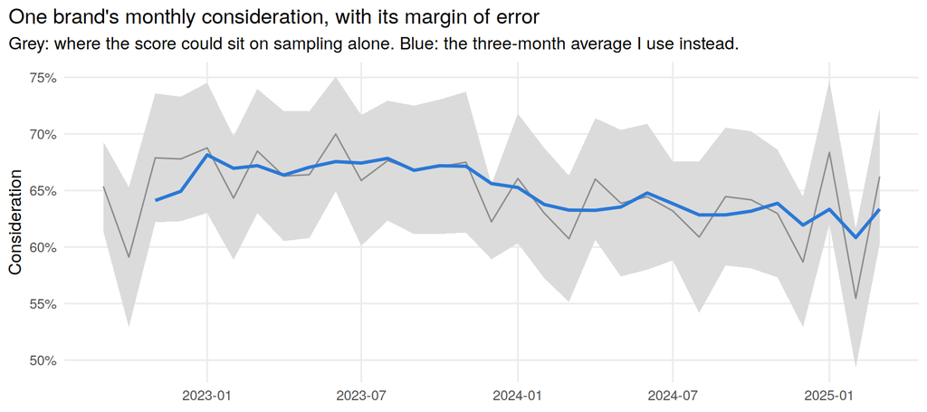

```r
eg <- survey |>
  filter(category_name == "Fast Food", brand_name == "KFC") |>
  arrange(wave_date) |>
  mutate(se = se_prop(consideration, base_n),
         q = zoo::rollmean(consideration, 3, fill = NA, align = "right"))

ggplot(eg, aes(wave_date, consideration)) +
  geom_ribbon(aes(ymin = consideration - 1.96 * se, ymax = consideration + 1.96 * se),
              fill = "grey86") +
  geom_line(color = "grey55", linewidth = .5) +
  geom_line(aes(y = q), color = PAL[1], linewidth = 1.1) +
  scale_y_continuous(labels = scales::percent) +
  labs(x = NULL, y = "Consideration",
       title = "One brand's monthly consideration, with its margin of error",
       subtitle = "Grey: where the score could sit on sampling alone. Blue: the three-month average I use instead.")
```

This isn’t a criticism of the survey. The blue line is the best available estimate and the fieldwork is doing its job. It’s about resolution. Ask 200 people and you can see a ten-point gap between brands; you can’t see a two-point move in one brand month to month. Treating every wiggle as real is what produces false alarms. So I compare quarters, not months.

Across all brands, by category:

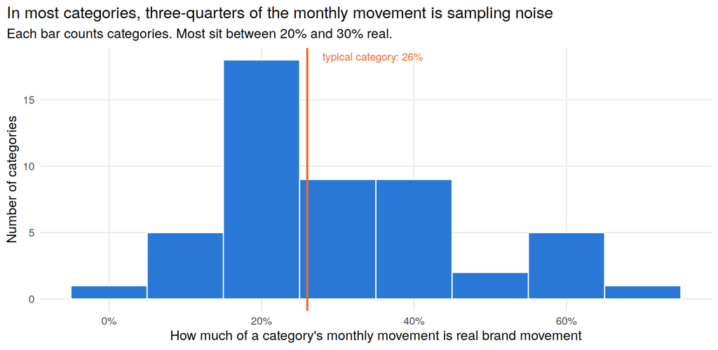

```r
nd <- noise_decomposition(survey, "consideration")
nd_cat <- nd |> filter(waves >= 12) |> group_by(category_name) |>
  summarise(real = mean(reliability, na.rm = TRUE), .groups = "drop")

ggplot(nd_cat, aes(real)) +
  geom_histogram(binwidth = .1, fill = PAL[1], color = "white") +
  geom_vline(xintercept = median(nd_cat$real), color = PAL[2], linewidth = .9) +
  annotate("text", x = median(nd_cat$real) + .02, y = Inf, vjust = 1.6, hjust = 0,
           label = "typical category: 26%", color = PAL[2], size = 3.4) +
  scale_x_continuous(labels = scales::percent) +
  labs(x = "How much of a category's monthly movement is real brand movement",
       y = "Number of categories",
       title = "In most categories, three-quarters of the monthly movement is sampling noise",
       subtitle = "Each bar counts categories. Most sit between 20% and 30% real.")
```

Each bar counts categories. They pile up between 20% and 30%. In the typical category, about a quarter of what you see moving is the brand moving. The rest is the sample changing.

This has two consequences.

- I use **quarterly** figures. Averaging three waves roughly halves the noise.
- There’s a hard ceiling on how well *anything* can correlate with monthly consideration. If a quarter of the movement is real, a perfect predictor is still chasing a mostly-noise target. The maximum correlation is the square root of the share that’s real — a quarter real caps you near 0.5, and across these brands it averages 0.48. A second identical survey would hit the same ceiling against the first. So a mediocre correlation tells you the ruler is wobbly, not that search is wrong.

The flip side: in small categories, search may be the steadier measure. And if Trends exposed even coarse demographics — Google clearly holds that signal, it’s what powers ad targeting — this comparison would get far more interesting, because audience cuts are the survey’s real advantage.

# 4. Does search rank brands like the funnel does?

For each category I compare brands on average share of search against average share of consideration, and ask whether the orderings agree. I use rank agreement (Spearman’s ρ) rather than comparing the shares directly: the question is whether search puts brands in the same order, not whether it reproduces the percentages, which it can’t.

1 means identical order, 0 means no relationship, negative means reversed.

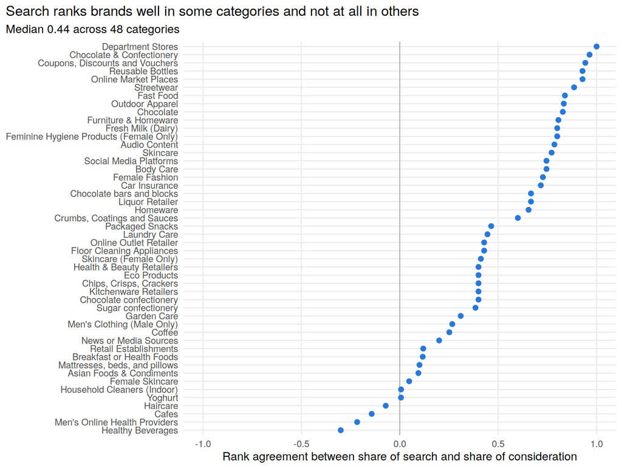

```r
between <- panel |>
  group_by(category_name, brand_name) |>
  summarise(sos = mean(sos), soc = mean(soc), sop = mean(sop), .groups = "drop")

between_cat <- between |>
  group_by(category_name) |>
  filter(n() >= 4) |>                  # 4+ brands for a rank to mean anything
  summarise(rho = cor(sos, soc, method = "spearman"), .groups = "drop")

ggplot(between_cat, aes(rho, reorder(category_name, rho))) +
  geom_vline(xintercept = 0, color = "grey70") +
  geom_point(color = PAL[1], size = 2.2) +
  scale_x_continuous(limits = c(-1, 1)) +
  labs(x = "Rank agreement between share of search and share of consideration",
       y = NULL,
       title = "Search ranks brands well in some categories and not at all in others",
       subtitle = paste0("Median ", round(median(between_cat$rho), 2),
                         " across ", nrow(between_cat), " categories"))
```

The spread is the finding, so both ends are worth being precise about.

**At the top**, search gets the order almost exactly right: department stores, online marketplaces, chocolate, streetwear. Categories where the brand name *is* the search — you type “Kmart” because you’re going to Kmart.

**At the bottom**, my first explanation was that nobody searches these categories. That’s wrong, and the real reasons are more useful:

```r
# For each weak category, the brand taking the most search, against its
# consideration. A brand pulling far more search than consideration is usually
# the culprit.
between_cat |>
  slice_min(rho, n = 4) |>
  left_join(between |> group_by(category_name) |> slice_max(sos, n = 1),
            by = "category_name") |>
  transmute(category = category_name, rho = round(rho, 2),
            `top search brand` = brand_name,
            `its search` = scales::percent(sos, 1),
            `its consideration` = scales::percent(soc, 1))
```

| category | rho | top search brand | its search | its consideration |
| --- | --- | --- | --- | --- |
| Healthy Beverages | -0.30 | Shine | 49% | 5% |
| Men’s Online Health Providers | -0.22 | Manscaped | 48% | 15% |
| Cafes | -0.14 | Krispy Kreme | 31% | 8% |
| Haircare | -0.07 | Fruits | 68% | 3% |

Three of those four are fixable with the same tooling that collected the data. The name-matching failures need the entity resolution I applied to my eight hand-checked categories, extended to the other 42. The generic survey option needs excluding from the share calculation. Only Cafes is a genuine limit.

Skincare settles the “nobody searches this” story: **Skincare scores 0.77 and Body Care 0.75**, while **Female Skincare scores 0.05** — dragged down by brands called *Software* and *Go-To*. These are the same shoppers behaving the same way in both categories, and the scores come out opposite. The brands dragging Female Skincare down are ordinary words that Google cannot tell apart from the brand, so the most likely explanation is my measurement rather than anything about the consumers.

So this chart mixes three things: categories where search genuinely tracks the funnel, categories where the purchase isn’t a branded search, and categories where my matching failed. The third group has an obvious fingerprint, which makes it screenable:

```r
# A brand holding a large share of search but almost no consideration is
# usually a name collision, not a hidden giant.
flagged <- between |> filter(sos > 0.2, sos > 4 * soc)
flagged |>
  arrange(desc(sos)) |>
  transmute(category = category_name, brand = brand_name,
            search = scales::percent(sos, 1),
            consideration = scales::percent(soc, 1))
```

| category | brand | search | consideration |
| --- | --- | --- | --- |
| Health & Beauty Retailers | Adore Beauty | 85% | 13% |
| Haircare | Fruits | 68% | 3% |
| Garden Care | Neutrog | 53% | 2% |
| Healthy Beverages | Shine | 49% | 5% |
| Female Skincare | Rationale | 43% | 8% |
| Asian Foods & Condiments | Roll’d | 40% | 9% |
| Chips, Crisps, Crackers | Burts | 31% | 2% |

This needs a human at the end of it. *Adore Beauty* is flagged and isn’t an error — it’s an online retailer, so searching the name **is** the shopping trip. The screen should raise a query, not delete a row.

**How much rides on seven brands?**

```r
rank_agreement <- function(d) {
  d |> group_by(category_name) |> filter(n() >= 4) |>
    summarise(rho = cor(sos, soc, method = "spearman"), .groups = "drop")
}
kept <- anti_join(between, flagged, by = c("category_name", "brand_name"))

tibble(version = c("As collected", "7 flagged brands removed"),
       `median rho` = c(round(median(rank_agreement(between)$rho), 2),
                        round(median(rank_agreement(kept)$rho), 2)),
       `categories 0.7+` = c(sum(rank_agreement(between)$rho >= .7),
                             sum(rank_agreement(kept)$rho >= .7)))
```

| version | median rho | categories 0.7+ |
| --- | --- | --- |
| As collected | 0.44 | 18 |
| 7 flagged brands removed | 0.59 | 19 |

Seven brands out of four hundred move the median from 0.44 to 0.59. Healthy Beverages goes from −0.30 to 0.40, Garden Care from 0.31 to 0.96, Female Skincare from 0.05 to 0.57.

The truth sits between the two rows — 0.44 understates search because my matching failed, 0.59 overstates it because dropping a brand also removes a real competitor from the denominator. Either way, the lesson is the same: **the quality of a share-of-search metric is set by the name matching, not the statistics.**

The brands that break the pattern in *good* categories break it for nameable reasons. Suncorp and RACQ pull more search than their insurance consideration warrants, because people search them for banking and roadside assistance. The Bottle-O over-indexes because “bottle-o” is what Australians call any liquor store — which isn’t noise, it’s a brand that became the generic term, like googling or ubering. A brand well above the line is worth a conversation, not a correction.

**A parallel from a category not in this sample.** Pet retail isn’t one of the 50 here, but it looks like the categories at the top of this chart: a few well-known chains, distinctive names, a purchase people research online. I built a marketing mix model for a pet retail brand that was holding sales flat through promotional depth while quietly losing market share and share of voice. The sales line looked fine; the brand indicators underneath it were eroding, and the promotions masked that in the only number the business was watching.

I used share of voice there as the leading indicator, and that is the same argument this study makes with search — share of search is the version you can get for every brand in a category without buying media data. It updates monthly, costs nothing, and doesn’t depend on a competitor’s spend being visible to you. That’s the whole appeal: the early-warning logic already works, this is a cheaper way to observe it.

# 5. Does search move with a brand over time?

Ranking brands against each other is static. The harder question is whether one brand’s search and consideration rise and fall together.

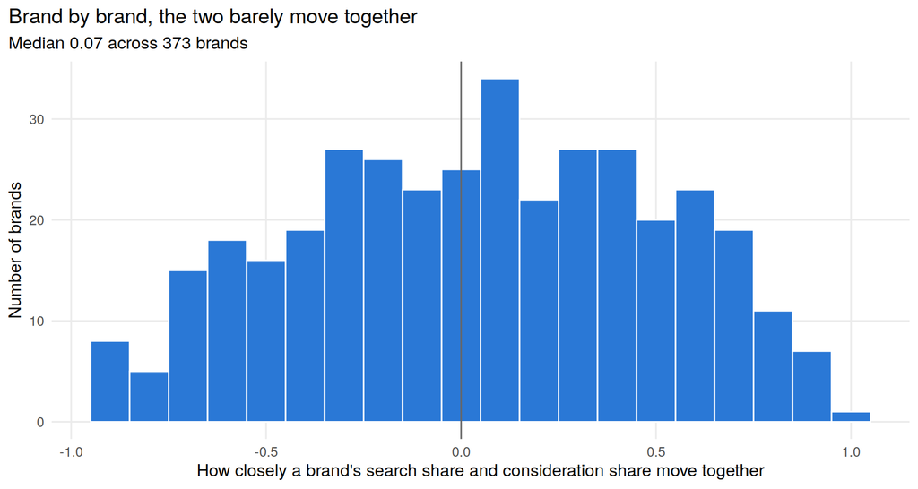

```r
# Collapse to quarters, then correlate each brand's own search share against
# its own consideration share over time.
q <- panel |>
  mutate(qtr = as.Date(cut(month, "quarter"))) |>
  group_by(category_name, brand_name, qtr) |>
  summarise(sos = mean(sos), soc = mean(soc), sop = mean(sop), .groups = "drop")

within_brand <- q |>
  group_by(category_name, brand_name) |>
  filter(n() >= 6, sd(sos) > 0, sd(soc) > 0) |>
  summarise(r = cor(sos, soc), .groups = "drop")

ggplot(within_brand, aes(r)) +
  geom_histogram(binwidth = .1, fill = PAL[1], color = "white") +
  geom_vline(xintercept = 0, color = "grey40") +
  labs(x = "How closely a brand's search share and consideration share move together",
       y = "Number of brands",
       title = "Brand by brand, the two barely move together",
       subtitle = paste0("Median ", round(median(within_brand$r), 2),
                         " across ", nrow(within_brand), " brands"))
```

A weak result, and it should be read as one. Some brands track well, more sit near zero, plenty are negative.

But a correlation this size isn’t a conclusion either way. Section 3 showed quarterly survey figures still carry real noise, and two noisy series can’t correlate strongly however well connected the underlying things are. This rules out search as a tight substitute for the survey. It doesn’t say search is uninformative.

The better move is to stop asking whether the lines move together and start asking what the distance between them means.

# 6. Demand a brand hasn’t converted yet

Marketers already trust a version of this idea. Binet and Field’s excess share of voice rule says a brand advertising at a bigger share than its market share tends to grow, and a brand under-investing tends to shrink. The gap between the two points the direction. (Summary and sources in `assumptions.md`.)

Search gives the same shape of measure without having to buy media data:

> **Excess Share of Search = share of search − share of consideration.** Positive means more people are actively looking for the brand than its consideration score implies. Negative means the brand is being claimed in surveys more than it is being sought out in real life.

For a CMO the two signs mean different things. A positive gap is an opportunity: there is demand out there that the brand has not yet converted into stated consideration, and it is usually cheaper to convert interest that already exists than to create it. A negative gap is a warning: the brand is living off reputation that is no longer showing up in behaviour.

One difference from Binet and Field is worth naming. Share of voice is an input a brand controls. Share of search is an output of everything the brand has already done. So the gap is a symptom to read, not a dial to turn.

Does today’s gap tell us where consideration goes over the next six months?

```r
esos <- q |>
  group_by(category_name, brand_name) |>
  mutate(esos = sos - soc, d_soc = lead(soc, 2) - soc, d_sop = lead(sop, 2) - sop) |>
  ungroup() |>
  filter(!is.na(d_soc))

esos |>
  mutate(group = if_else(esos > 0, "Searched more than considered",
                         "Considered more than searched")) |>
  group_by(group) |>
  summarise(`brand-quarters` = n(),
            `change in consideration share, 6 months later` =
              scales::percent(mean(d_soc), .01), .groups = "drop")
```

| group | brand-quarters | change in consideration share, 6 months later |
| --- | --- | --- |
| Considered more than searched | 1725 | -0.64% |
| Searched more than considered | 1034 | 0.30% |

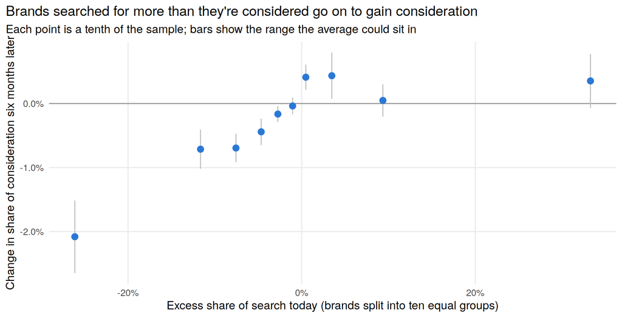

```r
esos |>
  mutate(bin = cut(esos, breaks = quantile(esos, seq(0, 1, .1)),
                   include.lowest = TRUE, labels = FALSE)) |>
  group_by(bin) |>
  summarise(esos = mean(esos), d = mean(d_soc), se = sd(d_soc) / sqrt(n())) |>
  ggplot(aes(esos, d)) +
  geom_hline(yintercept = 0, color = "grey60") +
  geom_errorbar(aes(ymin = d - 1.96 * se, ymax = d + 1.96 * se), width = 0,
                color = "grey75") +
  geom_point(color = PAL[1], size = 2.8) +
  scale_x_continuous(labels = scales::percent) +
  scale_y_continuous(labels = scales::percent) +
  labs(x = "Excess share of search today (brands split into ten equal groups)",
       y = "Change in share of consideration six months later",
       title = "Brands searched for more than they're considered go on to gain consideration",
       subtitle = "Each point is a tenth of the sample; bars show the range the average could sit in")
```

```r
tibble(stage = c("Consideration", "Preference"),
       effect = c(coef(lm(d_soc ~ esos + soc, data = esos))[["esos"]],
                  coef(lm(d_sop ~ esos + sop, data = esos))[["esos"]]),
       `std errors from 0` = c(
         summary(lm(d_soc ~ esos + soc, data = esos))$coefficients["esos", 3],
         summary(lm(d_sop ~ esos + sop, data = esos))$coefficients["esos", 3])) |>
  mutate(across(where(is.numeric), ~ round(.x, 2)))
```

| stage | effect | std errors from 0 |
| --- | --- | --- |
| Consideration | 0.03 | 8.14 |
| Preference | 0.03 | 7.51 |

A search surplus is associated with subsequent movement at both stages — consistent with the funnel sequence the study assumes, though association is as far as this design goes. Nothing here rules out a campaign lifting search, consideration and preference together on different lags.

**The obvious objection.** Share of consideration mean-reverts — a brand sitting high has more room to fall — and the gap is *mechanically* negative when consideration is high. So some of this could be regression to the mean in a costume. A second version: these are shares, so they’re zero-sum within a category. One brand’s gain is a rival’s loss. That’s what makes it competitive, but it also means a brand can look like it’s winning because a competitor collapsed. Controlling for starting level and category:

```r
# Cluster-robust standard errors. Each brand contributes ~7 quarterly
# observations, and brands in a category share seasonality, competitor moves
# and fieldwork effects — so ordinary standard errors treat correlated
# observations as independent and come out too small. This is the standard CR1
# sandwich estimator, written out rather than imported so the adjustment is
# visible: bread * meat * bread, with clusters summed inside the meat.
cluster_se <- function(fit, cluster) {
  X <- model.matrix(fit); u <- residuals(fit); bread <- solve(crossprod(X))
  cluster <- as.factor(cluster)
  G <- nlevels(cluster); n <- nrow(X); k <- ncol(X)
  meat <- matrix(0, k, k)
  for (g in levels(cluster)) {
    idx <- which(cluster == g)
    score <- crossprod(X[idx, , drop = FALSE], u[idx])
    meat <- meat + tcrossprod(score)
  }
  sqrt(diag(bread %*% meat %*% bread) * (G / (G - 1)) * ((n - 1) / (n - k)))
}

esos <- esos |> mutate(brand_id = paste(category_name, brand_name))

specs <- list(
  "Gap alone"          = d_soc ~ esos,
  "+ starting level"   = d_soc ~ esos + soc,
  "+ category effects" = d_soc ~ esos + soc + factor(category_name))

# Two-way clustering (Cameron, Gelbach & Miller): brands repeat over time AND
# brands within a category move together, so I want both. The variance is
# V(brand) + V(category) - V(brand-and-category), which stops the overlap
# being counted twice.
se_two_way <- function(fit, a, b) {
  v <- cluster_se(fit, a)^2 + cluster_se(fit, b)^2 -
       cluster_se(fit, paste(a, b))^2
  sqrt(pmax(v, 0))
}

# Degrees of freedom matter once errors are clustered: the reference
# distribution is t with (number of clusters - 1), not the residual df. With
# 409 brands that barely bites; with 50 categories it does.
n_brand <- n_distinct(esos$brand_id); n_cat <- n_distinct(esos$category_name)

purrr::imap_dfr(specs, function(f, nm) {
  fit <- lm(f, data = esos)
  b <- coef(fit)[["esos"]]
  t_brand <- b / cluster_se(fit, esos$brand_id)[["esos"]]
  t_two   <- b / se_two_way(fit, esos$brand_id, esos$category_name)[["esos"]]
  tibble(model = nm, effect = round(b, 3),
         `t, plain` = round(b / summary(fit)$coefficients["esos", 2], 2),
         `t, by brand` = round(t_brand, 2),
         `p, by brand` = round(2 * pt(-abs(t_brand), n_brand - 1), 3),
         `t, two-way` = round(t_two, 2),
         `p, two-way` = round(2 * pt(-abs(t_two), n_cat - 1), 3))
})
```

| model | effect | t, plain | t, by brand | p, by brand | t, two-way | p, two-way |
| --- | --- | --- | --- | --- | --- | --- |
| Gap alone | 0.036 | 11.52 | 4.46 | 0.000 | 3.12 | 0.003 |
| + starting level | 0.026 | 8.14 | 3.62 | 0.000 | 2.63 | 0.011 |
| + category effects | 0.020 | 6.44 | 2.85 | 0.005 | 2.12 | 0.039 |

Three columns because the standard errors matter here. Each brand shows up about seven times, and brands in the same category move together through shared seasonality, competitor activity and the same fieldwork. Plain standard errors treat all of those rows as independent, so they come out too small. Clustering by brand roughly doubles them. Clustering by brand and category widens them again. The effect holds in all three columns, but it is much less dramatic than the plain numbers make it look.

Controlling for the starting level also shrinks the effect, so part of the raw relationship was mean reversion.

**Where the signal actually lives.** Pushing further, the relationship is *between* brands rather than *within* one over time:

```r
# Between: collapse each brand to its averages — one row per brand, so no
# repeated observations at all. Within: subtract each brand's own average, so
# only its quarter-to-quarter deviations remain.
between_b <- esos |> group_by(brand_id) |>
  summarise(across(c(esos, d_soc, soc), mean), .groups = "drop")
within_b <- esos |> group_by(brand_id) |>
  mutate(across(c(esos, d_soc, soc), ~ .x - mean(.x))) |> ungroup()

purrr::imap_dfr(
  list("Between brands (one row per brand)" = between_b,
       "Within a brand over time"           = within_b),
  function(d, nm) {
    fit <- lm(d_soc ~ esos + soc, data = d)
    tibble(comparison = nm, effect = round(coef(fit)[["esos"]], 3),
           t = round(summary(fit)$coefficients["esos", 3], 2))
  })
```

| comparison | effect | t |
| --- | --- | --- |
| Between brands (one row per brand) | 0.016 | 3.77 |
| Within a brand over time | -0.036 | -2.53 |

Collapsing to one row per brand removes the repeated-observation problem, and the effect holds: brands that sit persistently above their category on search relative to consideration go on to gain consideration share. It does not make the rows fully independent, though — brands are still nested inside categories. Clustering this model by category as well takes it from t = 3.77 to t = 2.10 (p = 0.04), so it survives, but the panel model with two-way clustering is the better place to hang the inference. This decomposition is here to show *where* the relationship lives, not to carry the significance claim.

Within a brand it does not hold. A single brand’s quarter-to-quarter movement around its own average gap tells you nothing useful about where that brand goes next, and if anything it points the other way. This is disappointing, but it is consistent with what section 5 found. A single brand’s quarterly series is mostly noise, and no amount of rearranging the data fixes that.

**So this is a positioning signal, not a timing signal.** It can tell you which brands in a category look poised to gain or lose ground. It cannot tell you that your gap widened this quarter and therefore your brand is about to grow. That distinction belongs in the product spec rather than a footnote, because getting it wrong is the easiest way to ship a metric that embarrasses everyone.

**What the numbers mean.** The effect column is share points gained per share point of gap. Concretely, using the between-brand figure: **a brand sitting 10 points of search share above its consideration share gains something like 0.15 of a point of consideration share over six months** — 20% heading for 20.15%. That is a small effect and I am reporting it as one. It is a directional indicator, not a forecast, and the gap needs to be large and persistent to mean anything, which is exactly how excess share of voice is used in media planning.

This lines up with Tracksuit’s own [Return on Awareness](https://www.gotracksuit.com/report/return-on-awareness) work with Google, which finds share of search running ahead of market share by 6–12 months. Mine is the same story one step earlier: search runs ahead of consideration, which runs ahead of share.

**Does this work for small brands?** Commercially this is the question that matters — small brands have the thinnest survey samples. My first cut said no: splitting by awareness, the gap looked twice as strong for large brands. That didn’t survive checking. The flagged brands from §4 are small on consideration and huge on search by construction, so they sit in the small-brand half and drag it down.

```r
sized <- esos |>
  left_join(panel |> group_by(category_name, brand_name) |>
              summarise(awareness = mean(awareness), .groups = "drop"),
            by = c("category_name", "brand_name"))
cut_at <- median(sized$awareness, na.rm = TRUE)
eff <- function(d) round(coef(lm(d_soc ~ esos + soc, data = d))[["esos"]], 3)
small <- filter(sized, awareness < cut_at); large <- filter(sized, awareness >= cut_at)

tibble(brands = c("Smaller", "Larger"),
       `as collected` = c(eff(small), eff(large)),
       `flagged removed` = c(
         eff(anti_join(small, flagged, by = c("category_name", "brand_name"))),
         eff(anti_join(large, flagged, by = c("category_name", "brand_name")))))
```

| brands | as collected | flagged removed |
| --- | --- | --- |
| Smaller | 0.014 | 0.029 |
| Larger | 0.033 | 0.033 |

With those seven out, small and large brands behave almost identically. Fitting the difference directly as an interaction says the same thing: the gap between the two groups is 0.001 with p = 0.89, so there is no detectable difference by brand size. The apparent weakness on small brands was my measurement error rather than a property of small brands. That is better news commercially, and a better fit with Return on Awareness, which finds the awareness-to-search link strongest among low and mid-awareness brands.

**Does the qualification test from §4 actually predict a stronger gap?** It should, if the two halves of this study are measuring the same thing, and it is the obvious way to check that §4’s threshold is doing real work rather than sorting categories on nothing.

```r
# Split the gap test by whether the category passed the ranking gate in §4.
rank_gate <- between |>
  group_by(category_name) |> filter(n() >= 4) |>
  summarise(rho = cor(sos, soc, method = "spearman"), .groups = "drop") |>
  mutate(passes = rho >= 0.7)

gated <- esos |> inner_join(rank_gate, by = "category_name")

purrr::map_dfr(c(TRUE, FALSE), function(g) {
  d <- filter(gated, passes == g)
  fit <- lm(d_soc ~ esos + soc, data = d)
  b <- coef(fit)[["esos"]]
  t <- b / cluster_se(fit, d$brand_id)[["esos"]]
  tibble(categories = if (g) "Pass the §4 gate" else "Fail the §4 gate",
         n_categories = n_distinct(d$category_name),
         effect = round(b, 3), `t, clustered` = round(t, 2))
})
```

| categories | n_categories | effect | t, clustered |
| --- | --- | --- | --- |
| Pass the §4 gate | 18 | 0.067 | 3.54 |
| Fail the §4 gate | 30 | 0.017 | 3.05 |

It also sharpens the recommendation. The gap works everywhere to some degree, but it works *well* in the categories that pass, which means the qualification test is a targeting rule rather than a gate that excludes clients from something valuable.

**The product version.** One flag on the brand dashboard — “search demand running ahead of consideration” — plus a quadrant chart placing every brand in the category on search surplus against consideration. The step after that is translating the gap into dollar terms through a marketing mix model — which is where a CMO can defend or argue for an investment level in a board meeting, and where brand measurement starts behaving like financial reporting.

# 7. How long does search take to show up?

If search leads consideration, by how long? Marketing mix models answer this with **carryover**: activity doesn’t act all at once and doesn’t stop dead, it fades. I use the simplest version — carry some share of last quarter’s search into this quarter, try every share, keep whichever fits best.

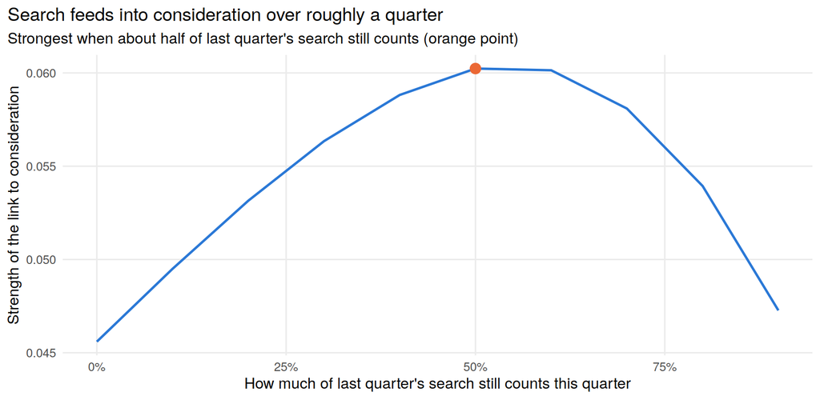

```r
# Standard adstock:
#   effective search this quarter = (1-k) * this quarter + k * last quarter's
# k is the share carried over. The (1-k) weight matters: without it, higher k
# just inflates the numbers and "improves" the fit for arithmetic reasons.
adstock <- function(x, k) {
  out <- numeric(length(x)); out[1] <- x[1]
  for (i in seq_along(x)[-1]) out[i] <- (1 - k) * x[i] + k * out[i - 1]
  out
}

carry <- purrr::map_dfr(seq(0, 0.9, by = 0.1), function(k) {
  d <- q |>
    group_by(category_name, brand_name) |>
    filter(n() >= 6) |>
    mutate(search = as.numeric(scale(adstock(sos, k))),      # standardise within
           consideration = as.numeric(scale(soc))) |>        # brand so all count equally
    ungroup() |>
    filter(is.finite(search), is.finite(consideration))
  fit <- lm(consideration ~ search, data = d)
  tibble(carryover = k, strength = coef(fit)[["search"]], fit = summary(fit)$r.squared)
})
best <- carry |> slice_max(fit, n = 1)

ggplot(carry, aes(carryover, strength)) +
  geom_line(color = PAL[1], linewidth = .9) +
  geom_point(data = best, color = PAL[2], size = 3.6) +
  scale_x_continuous(labels = scales::percent) +
  labs(x = "How much of last quarter's search still counts this quarter",
       y = "Strength of the link to consideration",
       title = "Search feeds into consideration over roughly a quarter",
       subtitle = "Strongest when about half of last quarter's search still counts (orange point)")
```

The best fit carries about half of last quarter’s search into this one, which would put most of a search surge’s association with consideration inside about three months. Treat that as an **exploratory timing estimate**, not a measurement: I picked the carryover rate by seeing which of ten values fitted this same data best, so the winner is partly a property of the search rather than of the world. It agrees with a separate, cruder check — shifting the search series forward two to three months maximises its agreement with consideration — which is reassuring but not independent evidence.

**Does this contradict Return on Awareness?** No. They find search leading *market share* by 6–12 months; I find it leading *consideration* by about three. Consideration is earlier and faster-moving than sales, so a shorter lead is what you’d expect. Together they describe one chain: search moves first, consideration follows within a quarter, market share follows over the year.

**A fair objection to the whole idea of a lead.** You could argue that people have to be considering a brand before they search for it, in which case search cannot precede consideration at all. I think that objection is right about the consumer and wrong about the measurement. Searching a brand probably *is* consideration, expressed as behaviour rather than as a survey answer. The survey then asks about that same mental state weeks later, on a monthly wave, and averages it across 200 people. Both stories produce the lag I observe, and this data cannot separate them.

For the product it does not matter much which is true. Whether search leads consideration or simply observes it earlier and more cheaply, the practical consequence is the same: you see the movement sooner. It matters a lot for how the finding gets described, though, which is why I am not calling search a cause of anything.

# 8. Does it hold up?

The obvious way this could be an illusion: if everyone searches ice cream in summer *and* considers ice cream in summer, every brand looks connected without any brand-level signal.

So I broke the brand link deliberately. Each brand keeps its own consideration history but gets a *rival’s* search history from the same category — preserving category seasonality, destroying the brand connection. A hundred times over, that gives the range of results the data produces when there’s nothing real to find.

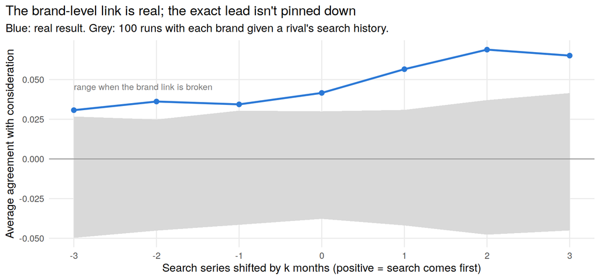

```r
# Grey band: 95% range across 100 brand-shuffled runs. Blue: the real result at
# each shift of the search series.
plc <- out("leadlag_placebo.csv")
band <- plc |> filter(run != "real") |> group_by(lag_months) |>
  summarise(lo = quantile(mean_r, .025), hi = quantile(mean_r, .975))
ggplot() +
  geom_ribbon(data = band, aes(lag_months, ymin = lo, ymax = hi), fill = "grey85") +
  geom_hline(yintercept = 0, color = "grey60") +
  geom_line(data = filter(plc, run == "real"), aes(lag_months, mean_r),
            color = PAL[1], linewidth = 1) +
  geom_point(data = filter(plc, run == "real"), aes(lag_months, mean_r),
             color = PAL[1], size = 2.2) +
  annotate("text", x = -3, y = max(band$hi), hjust = 0, vjust = -0.5, size = 3.3,
           color = "grey45", label = "range when the brand link is broken") +
  scale_x_continuous(breaks = -3:3) +
  labs(x = "Search series shifted by k months (positive = search comes first)",
       y = "Average agreement with consideration",
       title = "The brand-level link is real; the exact lead isn't pinned down",
       subtitle = "Blue: real result. Grey: 100 runs with each brand given a rival's search history.")
```

Two claims here, with different strength.

**The brand-level signal is real.** The blue line sits above the grey band at every shift. If this were only category seasonality, swapping in a rival’s search history would cost nothing and the blue line would sit inside the band. It does not, so I am comfortable with this claim.

**The 2–3 month lead is not proven.** The line does peak at a two-to-three month lead, but about one in seven shuffles produces a tilt that large. So: direction supported, length unproven.

One limitation of the test: the shuffle stays inside the category, so if two brands genuinely move together the placebo inherits some of that. It’s a conservative test, which is why I’m comfortable with the first claim and cautious on the second.

The three findings do not carry equal weight, so it is worth setting them out side by side:

| Finding | Evidence |
| --- | --- |
| Search carries brand-level information beyond category seasonality | Strong |
| Brands with a search surplus tend to gain consideration afterwards | Moderate — holds between brands with clustered errors, not within a brand |
| Search leads consideration by 2–3 months | Exploratory — direction consistent, size not established |

The first result is solid on this data. The second is strong enough to build a directional product on, provided a holdout test runs alongside it. The third is a hypothesis worth testing rather than a finding.

**Other checks.** Raising the search-volume bar doesn’t change the ranking result (0.44 to 0.47 as the cut-off rises). The gap result holds within categories as well as across them, and at both funnel stages. Every brand whose search identifier came back empty was automatically re-collected under its plain name, so “no volume” means no demand rather than a lookup failure.

## What would actually establish cause

Nothing here is causal, and it is worth being specific about why, because “observational study” on its own is not much of an explanation.

Three things block it. Campaigns move search and consideration together on different lags, so a common driver produces the pattern I see. Causation could run the other way, since a brand people already consider is a brand people search. And as section 7 argues, searching a brand may simply *be* consideration observed earlier, in which case there is no sequence to explain.

What would settle it, roughly in order of strength:

- **Geo or matched-market experiments.** Run brand activity in some regions and not others, then watch both search and the survey in each. Randomised exposure, so the comparison is clean. Tracksuit is well placed for this because it already fields the survey by market.
- **Brand lift studies.** Randomised exposure at the individual level, which answers whether the activity moved the metric, though not directly whether search precedes consideration.
- **Difference-in-differences around known campaign launches.** No experiment required — compare a brand’s search and consideration before and after a launch against similar brands that did not launch. Weaker than randomisation and it needs a defensible control group, but it can be run on data Tracksuit already holds.

**Where marketing mix modelling fits.** An MMM would attribute movement to spend while controlling for other drivers, and would put a dollar figure on the gap, which is what makes it useful to a CMO. But it is still observational: its causal claim rests on the model being specified correctly, not on randomisation. So MMM is how you would *value* this effect. Experiments are how you would *prove* it. Both are worth doing, in that order, and neither fits in a pilot.

**Next, in priority order:** test the signal on later waves it hasn’t seen; fix the name matching in the weak categories and re-run §4; re-collect search at weekly granularity so the lag can be estimated properly; and check whether the gap predicts preference *conversion* rather than preference share.

# 9. Next potential steps

Taking this from a pilot to something usable, in roughly the order the work would need to happen.

**A directional layer rather than a replacement.** The survey says where a client stands. The gap says which way they are heading between waves. That is an addition to a brand tracker rather than a cheaper version of one, and it answers a real frustration, which is waiting a month for a number that mostly moves on noise.

**Where it fills gaps.** It fills *time* well: continuous, so it covers the months between waves and flags movement before the next wave confirms it. On *brands* the answer improved once I fixed the contamination — the gap works about as well for small brands as large ones, so this isn’t a big-brands-only tool.

The real brand-level limit is a reporting threshold, not missing demand. Trends rounds to a 0–100 index within each comparison, so a brand competing against a much larger rival reads as zero even with real, steady search. “Nobody searches this brand” and “this brand is too small to show up next to Bunnings” are very different claims, and I can’t separate them with public data. Two things would: pulling small brands against each other rather than the category leader, and the granular volumes a Google partnership feed provides. So 1 in 5 is an upper bound on genuine invisibility, not a measurement of it.

**On qualifying categories.** A category qualifies when most of its brands have measurable search and search reproduces the funnel’s ranking. The 0.7 rank agreement I use as the line is an operational threshold, not a statistically optimised one — it’s roughly where a category’s top few brands come out in the right order, which is what a client actually looks at. It should be calibrated against client outcomes rather than my judgement. About a third pass today — and a chunk of the rest fail on name matching, not consumer behaviour, so that share rises with better data engineering.

The case for shipping narrow and early is stronger than holding it back until every category works. A qualification gate is friction, but it is cheap friction, since it is a query over data Tracksuit already holds, and it buys the freedom to put the metric in front of clients now. Shipping is also how the marketing science improves: a client who sees their gap turn negative, acts on it, and watches the next two waves gives me forward-looking validation I can’t get from a historical dataset. Not a clean experiment — they chose when to act — but ten of those beat another round of my own robustness checks.

The thing worth protecting is the failure mode. Breaking things is fine when being wrong costs a shrug. It gets expensive when a client opens the dashboard and sees a brand called *Fruits* leading haircare, because they then stop trusting every other number on the page. Shipping fast where the category passes, labelling it directional, and keeping the contamination screen running covers most of that risk.

**A risk worth designing around: this metric is gameable.** Surveyed consideration is expensive to move — you have to change what people actually think. Share of search is not. Brand-term SEO, a burst of search activation, or a competitor’s PR crisis will move a brand’s gap without anything real changing underneath. That is tolerable while the metric is directional and unpriced. It becomes a problem the moment it lands in a client’s KPI deck, because we would have created an incentive to optimise the measurement rather than the brand. If this ships, it should ship with that stated, and probably with a rule that the flag is read alongside the survey rather than instead of it.

**What search can’t do.** No funnel stages. No absolute levels — a relative index never says “23% of the category considers you”. No audience cuts, at least not from public data; Google holds demographic and location signal internally, so a partnership feed may look very different. Those are the survey’s advantages.

**Where this fits.** Tracksuit already has a Google partnership behind Return on Awareness. Most limits here — relative indices, sampling wobble, brands that can’t be identified — come from using free public data, not from search itself. So the useful part isn’t my specific numbers. It’s the method: how to decide where a search metric can be trusted, how to check it isn’t measuring the wrong thing, and how to test whether the effect survives the obvious objections.

**Packaging.** The directional flag belongs in the base tracker — it makes the product stickier between waves and costs almost nothing to produce. What justifies a higher tier is the engineering behind a trustworthy version: curated brand-term matching for a client’s own competitive set, category qualification, alerting. Charging for the flag would be charging for something nearly free. Charging for the work that makes it reliable is defensible — and that work is getting cheaper, so I’d re-measure what a curated competitive set costs to build and maintain today before pricing it off last year’s number.

# Appendix A: getting the data

Google Trends compares at most five terms per request and returns an index scaled within that request only. To put every brand in a category on one scale, the best-known brand rides along in every request as an anchor, and each batch is rescaled to it.

The harder problem is knowing what to search for. “Koala” is a mattress company and an animal; “Mecca” is a beauty retailer and a city. Where Google’s knowledge graph has an entry for the brand I use that instead of the words, with hand-written rules for the rest, and every decision written to a log.

I hand-checked terms for eight categories and let automation handle the rest. That’s exactly where §4’s weakest categories came from. A deliberate trade to keep this inside the time available, and the first thing I’d fix.

**Granularity.** Google decides what frequency it returns based on the window you ask for, and a 43-month window comes back monthly. So monthly is what I have, and it is Google’s aggregation rather than mine. Pulling in shorter windows would return weekly or daily data that I could aggregate myself, which is the better habit — smooth late, not early.

For the main results this changes nothing. I compare quarters anyway, and the survey only exists monthly, so no information is being lost on the side that binds. It does matter for section 7. With weekly search I could estimate the lag in weeks rather than whole months, and the timing estimate is the weakest part of this study. The cost is roughly six times the requests, or about nine hours instead of ninety minutes, which is why it did not happen here. If the timing question mattered commercially, this is the change I would make first.

Re-running everything on raw brand names with no cleaning changes the category-level answers very little: median rank agreement 0.55 uncurated versus 0.53 curated, across the 44 categories where both versions have enough brands. Rank comparisons forgive a few misplaced brands. At brand level the errors are wild in both directions — uncurated, “Ultimate” yoghurt looks thousands of times bigger than it is, while Kärcher and Roll’d vanish over an umlaut and an apostrophe.

So the cleaning barely matters for category research, and is essential for anything a client sees with their own brand’s name on it.

# Appendix B: method notes

- **Share of search** = a brand’s index ÷ the category total, monthly, among brands clearing the volume bar.
- **Margin of error and real movement.** Expected sampling variance per brand is `mean(p(1-p)/n)` across waves, where `n` is the weight of respondents who qualified for the category. Real movement is what’s left of observed variance after subtracting it. Maximum correlation against a perfect predictor is the square root of that share. Weights are treated as respondent counts, which flatters the survey.
- **Carryover** uses the normalised form `(1-k)·search + k·previous`. The unnormalised version in most MMM material inflates the series as `k` rises, so a search over `k` picks whichever value manufactures the strongest trend. Worth knowing before trusting an off-the-shelf implementation.
- **Assumptions and theory:** `assumptions.md`.
- **Reproducing:** `Rscript run_all.R` rebuilds every number and this document from the committed raw data. Versions in `session-info.txt`.